# Week 4 Exam

*Preparation*  
Let’s first plan out how the data flows will work by identifying what packages, functions and data we need.

*Packages to load* - sf  
- dplyr  
- tidyverse  
- here  
- readxl  
- janitor  
- stringr  
- tmap

*Functions* - read_xlsx  
- st_layers  
- filter  
- read.csv  
- mutate  
- pivot  
- cleannames

*Data*  
Gender Inequality Index for 2010 and 2019  
World Dataset - https://services.arcgis.com/P3ePLMYs2RVChkJx/arcgis/rest/services/World_Countries_(Generalized)/FeatureServer/0/query?outFields=*&where=1%3D1&f=geojson  
Also, we can plan what our basic process will be and what the expected outputs are:

*Process*  
- load packages  
- read data  
- clean names  
- pivot wider  
- mutate column to calculate difference between indexes  
- show difference on map  
- save output

*Output*  
- Shapefile of differences  
- CSV of differences

*Code*

By following our plan above we start by loading the required packages.

```r
library(sf)
library(dplyr)
library(tidyverse)
library(here)
library(readxl)
library(janitor)
library(stringr)
library(tmap)
```

Next we will read in the required data. In this case the Gender Inequality Index data whihc was downloaded from https://hdr.undp.org/data-center/documentation-and-downloads and also the world geometries geojson.

```r
# read gender data and prepare the relevant columns
gii_raw <- readxl::read_xlsx(here::here("data", "GenderInequalityIndex2010_2019.xlsx")) %>%
  janitor::clean_names() %>%
  dplyr::select(country_iso_code,country, year, value)

# read geometries and prepare columns
world <- sf::st_read("https://services.arcgis.com/P3ePLMYs2RVChkJx/arcgis/rest/services/World_Countries_(Generalized)/FeatureServer/0/query?outFields=*&where=1%3D1&f=geojson") %>%
  janitor::clean_names() %>%
  dplyr::select(country, iso, geometry)
```

Now we need to prepare the gender data, firstly by removing any regions from the GII country column.

```r
# create data frame and filter to only countries (exclude regions)
gii_filtered <- data.frame(gii_raw) %>%
  filter(str_detect(gii_raw$country_iso_code,"ZZ",TRUE))
```

We now pivot the data so it is in a usable format, rename the columns and create a new column that calculates the difference between the 2019 and 2010 index values.

```r
# pivot gii data
gii_wider <- gii_filtered %>%
  pivot_wider(names_from = "year",values_from = "value")

#rename value columns for ease of use
gii_wider <- gii_wider %>% dplyr::rename(value2010 = "2010", value2019 = "2019")

# create new column showing difference between 2019 and 2010 values
gii_new <- gii_wider %>%
  mutate(., difference=(value2019-value2010))
```

Then spatialise the data by joining the GII data with the world geometries geojson that was read in earlier.

```r
# spatialise the data by joining to world file
world_gii_spatial <- world %>%
  left_join(.,
            gii_new,
            by = c("country"="country"))
```

We can view the data on a map at this stage usibg tmap.

```r
# view the data on a map
tmap_mode("plot")
```

```
## tmap mode set to plotting
```

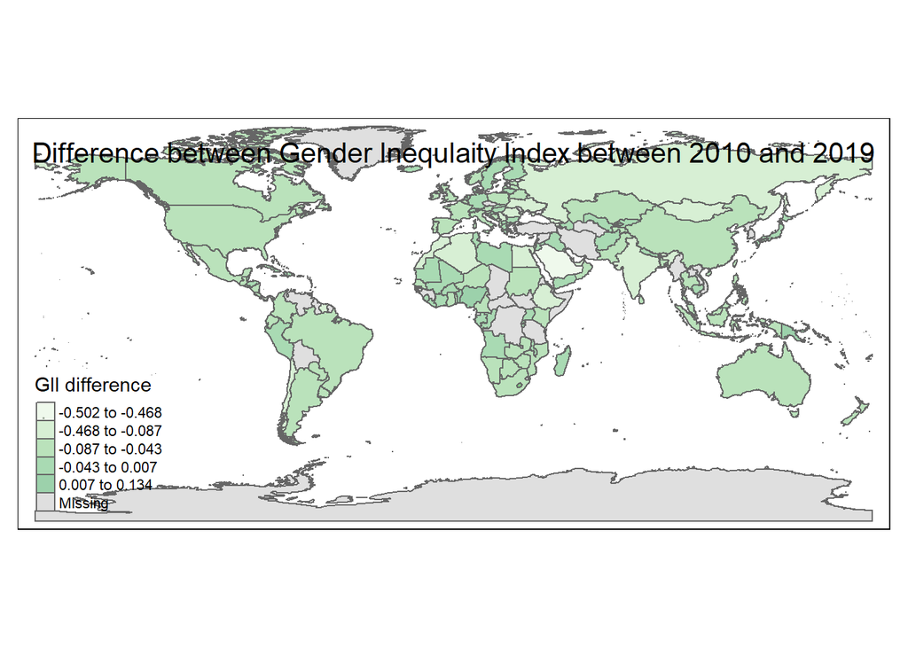

```r
tm_shape(world_gii_spatial) +
  tm_polygons("difference",
              style="jenks",
              palette="Greens",
              midpoint=NA,
              title="GII difference",
              alpha = 0.5) +
  tm_basemap(server = "OpenStreetMap") +
  tm_layout(title = "Difference between Gender Inequlaity Index between 2010 and 2019")
```

The final stage is to write the data to a CSV and a shapefile.

```r
# write data csv and shapefile
write.csv(gii_new, file = here::here("output", "GenderInequalityIndexWorld.csv"))
st_write(world_gii_spatial, "output/GenderInequalityIndexMap.shp", append=FALSE)
```

```
## Deleting layer `GenderInequalityIndexMap' using driver `ESRI Shapefile'
## Writing layer `GenderInequalityIndexMap' to data source
##   `output/GenderInequalityIndexMap.shp' using driver `ESRI Shapefile'
## Writing 251 features with 6 fields and geometry type Multi Polygon.
```